# ggrob_OriginalHomeworkCode_02

Gianna Grob

9/16/2019

# Introduction

This is the code for [Homework 2](https://fuzzyatelin.github.io/bioanth-stats/homework-02.html), on week three of AN597. This homework is associated with [Module 6](https://fuzzyatelin.github.io/bioanth-stats/module-06/module-06.html), [Module 7](https://fuzzyatelin.github.io/bioanth-stats/module-07/module-07.html), and [Module 8](https://fuzzyatelin.github.io/bioanth-stats/module-08/module-08.html#probability_mass_functions).

The information for the question is as follows:

> Every Saturday morning, at the same time, a primatologist goes and sits in the forest to listen for titi monkey calls, counting the number of calls they hear in a 2 hour window from 5am to 7am. Based on previous knowledge, she believes that the mean number of calls she will hear in that time is exactly 15. Let X represent the appropriate Poisson random variable of the number of calls heard in each monitoring session.

## Question 1

What is the probability that she will hear more than 8 calls during any given session?

```r
ppois(8, lambda = 15, lower=FALSE) #Find the upper tail for more than 8 calls in a session
```

```
## [1] 0.9625535
```

## Question 2

What is the probability that she will hear no calls in a session?

```r
dpois(0, lambda = 15) #Test for 0 calls in a session
```

```
## [1] 3.059023e-07
```

The chance of hearing 0 calls is very low with an occurance of 3.06e-07.

## Question 3

What is the probability that she will hear exactly 3 calls in a session?

```r
dpois(3, lambda = 15) #Find chance of hearing exactly 3 calls.
```

```
## [1] 0.0001720701
```

The probability she will hear exactly 3 calls will be 0.00017.

## Question 4

Plot the relevant Poisson mass function over the values in range 0 ≤ x ≤ 30.

[figure not shown]

```r
x <- 0:30 #Set our range of 0 to 30
l <- 15 #Set our lambda value as the amount of calls heard which is 15.
barplot(ppois(q=x,lambda=l),ylim=0:1,space=0, names.arg=x,xlab="x",ylab="Pr(X ≤ x)",main="Cumulative Probability") #Create barplot with the two varibles for cumulative probability
```

Note: Is that the graph he wants????

## Question 5

Simulate 104 results from this distribution (i.e., 2 years of Saturday monitoring sessions).

```r
rpois(104,15) #Set-up a simulation for 104 results for our lambda value of 15
```

```
##   [1] 16 12 14 18 19 16 13 13  9 16 14 13 20 18 13 20 18 11 21 16 12 20 19
##  [24] 17 13 13 15 20 14 19 14 14 15 11 15 15 14 12  6 18 16 19 15 13 14 18
##  [47] 16 19 16 13  8 18 12 14 17 13 20 16 21 14 16 13 14 16 19 16 17 19 21
##  [70] 15 18 10 22 11 13 15 24 10 17 22 14 14 14 16 12 16 13 13 18 14 11 14
##  [93] 17 10 19 13 15 15 14 14 17 17 17  9
```

Results will be different every time since it is a simulation, but the above code will simulate 104 results with different amount of calls heard.

## Question 6

Plot the simulated results using hist() and use xlim() to set the horizontal limits to be from 0 to 30. How does your histogram compare to the shape of the probability mass function you plotted above?

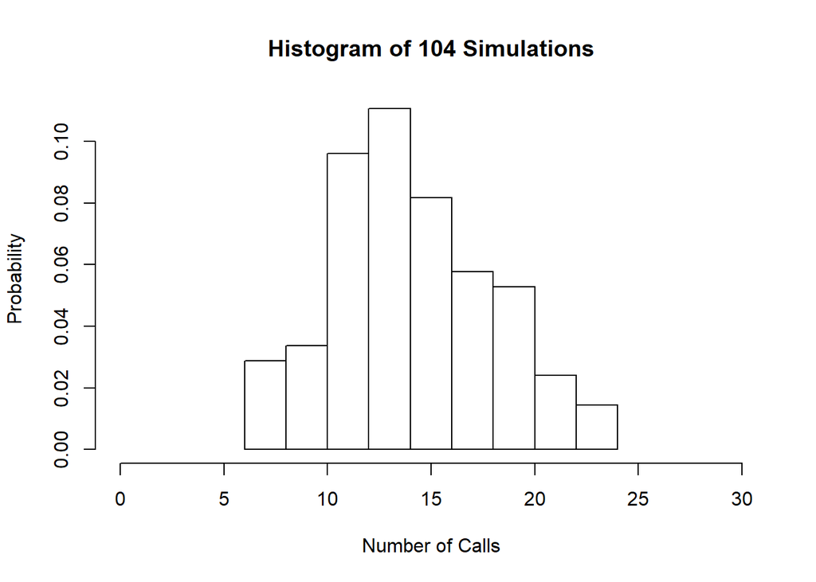

```r
x <- rpois(104,15) #Create a vector that is our simulation from above
hist(x, xlim = c(0,30), main = "Histogram of 104 Simulations", xlab = "Number of Calls", ylab = "Probability", probability = TRUE) #Create histogram with simulation with range from 0 to 30.
```

Note: In my histogram I set probability to TRUE to allow for probabiltiy to be shown. I have seen this in examples online. Is that needed for this graph?

### Challenges Faced

1. Learning how to do probability problems.
2. Creating a graph for Question 4, not sure if I made the correct one. Just used one off the modules.
3. Creating the histogram. Is the probabilty addition necessary? With and without gives a graph, but they look different.